# MDA2025-U8-Losungen

```python
import numpy as np
import matplotlib.pyplot as plt
import matplotlib.cm as cm

import warnings
warnings.filterwarnings(action='ignore')
```

### Koordinatensysteme

1. Ein vom konstanten Strom $I$ durchflossener linearer Leiter erzeugt in seiner Umgebung ein ringförmiges Magnetfeld, das in einer Schnittebene senkrecht zur Leiterachse durch das ebene Vektorfeld

$$ \mathbf{\vec{H}} = \dfrac{I}{2 \pi (x^2 + y^2)} \left[\begin{array}{c} -y \\ x \end{array}\right] $$

beschrieben wird. Wie lautet die Darstellung von $\mathbf{\vec{H}}$ in Polarkoordinaten?

2. Stelle den Ortsvektor der Mantelfläche eines Zylinders (Radius $r=5$, Höhe $h=2$) im kartesischen Koordinatensystem dar.
3. Stellen Sie das Vektorfeld $$x\mathbf{\vec{e}}_x - z\mathbf{\vec{e}}_y + y\mathbf{\vec{e}}_z$$ in Kugelkoordinaten dar.
4. Die Bahnkurve eines Masseteilchens besitzt den folgenden Ortsvektor $\mathbf{\vec{r}} = \left[\begin{array}{c} x(t) \\ y(t) \\ z(t) \end{array}\right] = \left[\begin{array}{c} \mathrm{e}^{-t} \cos(t) \\ \mathrm{e}^{-t} \sin(t) \\ 2t \end{array}\right]$. Wie lautet der zugehörige Geschwindigkeitsvektor dargestellt im Zylinderkoordinatensystem?

#### Lösung

*1)*

- Umrechnung der Variablen von kartesisch in polar: $\begin{array}{l}x=r\cdot\cos\varphi\\ y=r\cdot\sin\varphi \end{array}$

$\mathbf{\vec{H}}_{kartesisch} = \dfrac{I}{2 \pi (x^2+y^2)} \left[\begin{array}{c} -y \\ x \end{array}\right] = \dfrac{I}{2 \pi (r^2\cos^2\varphi+r^2\sin^2\varphi)} \left[\begin{array}{c} -r \sin\varphi \\ r \cos\varphi \end{array}\right] = \dfrac{Ir}{2 \pi r^2(\underbrace{\cos^2\varphi+\sin^2\varphi}_{1})} \left[\begin{array}{c} - \sin\varphi \\ \cos\varphi \end{array}\right] = \dfrac{I}{2 \pi r} \left(-\sin(\varphi) \mathbf{\vec{e}}_x + \cos(\varphi) \mathbf{\vec{e}}_y \right)$

- Umrechnung der Koordinaten von kartesisch zu polar: $\mathbf{\vec{H}}_{polar} = A\mathbf{\vec{H}}_{kartesisch}$  
  $A$ ist die Übergangsmatrix von der Basis $\mathbf{\vec{e}}_x,\mathbf{\vec{e}}_y$ zur Basis $\mathbf{\vec{e}}_r, \mathbf{\vec{e}}_\varphi$: $A=\begin{bmatrix} \cos\varphi & \sin\varphi\\ -\sin\varphi & \cos\varphi \end{bmatrix}$

$\mathbf{\vec{H}}_{polar} = \dfrac{I}{2\pi r}\left[\begin{array}{cc} \cos(\varphi) & \sin(\varphi) \\ -\sin(\varphi) & \cos(\varphi) \end{array}\right] \begin{bmatrix}-\sin\varphi\\ \cos\varphi \end{bmatrix} = \dfrac{I}{2 \pi r} \left[\begin{array}{c} -\sin\varphi\cos\varphi+\sin\varphi\cos\varphi \\ \sin^2\varphi+\cos^2\varphi \end{array}\right] = \dfrac{I}{2 \pi r} \left[\begin{array}{c} 0 \\ 1 \end{array}\right] = \dfrac{I}{2 \pi r}\mathbf{\vec{e}}_{\varphi}$

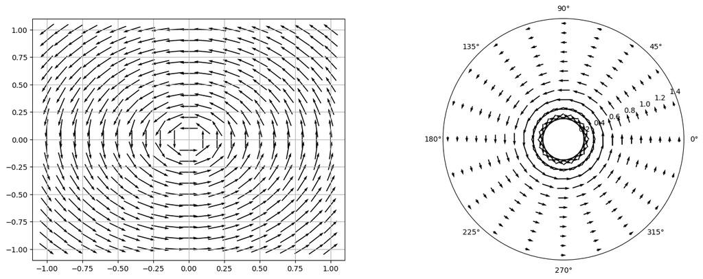

```python
x = np.linspace(-1,1,21)
y = np.linspace(-1,1,21)
X,Y = np.meshgrid(x,y)

fig = plt.figure(figsize=(17,6))
ax1 = fig.add_subplot(121)
U = -Y/np.sqrt(X**2 + Y**2)
V = X/np.sqrt(X**2 + Y**2)
ax1.quiver(X,Y,U,V, units='xy', angles='xy', scale=7, pivot='mid')
ax1.grid()

ax2 = fig.add_subplot(122, projection='polar')
r = np.linspace(0.25,np.sqrt(2),11)
phi = np.linspace(0,2*np.pi,21)
rr,pp = np.meshgrid(r,phi)
ax2.quiver(pp,rr,rr**(-1),np.zeros_like(rr), units='xy',angles='xy', scale=7, pivot='mid')
ax2.grid()
plt.show()
```

*2)*

Mantelfläche eines Zylinders hat einen konstanten Radius ($r=5$) und veränderlichen Winkel und Höhe. Im Zylinderkoordinatensystem stellt sich der Ortsvektor der Mantelfläche als

$$ \mathbf{\vec{r}_{ZK}} = 5 \mathbf{\vec{e}_r} + 0\mathbf{\vec{e}_\varphi} + \beta \mathbf{\vec{e}_z} $$

mit $0 \le \beta \le 2$.

Umrechnung in kartesische Koordinaten:

$$ \mathbf{\vec{r}_{KK}} = \left[\begin{array}{c} \cos(\varphi) & -\sin(\varphi) & 0 \\ \sin(\varphi) & \cos(\varphi) & 0 \\ 0 & 0 & 1\end{array}\right]\mathbf{\vec{r}_{ZK}} = \left[\begin{array}{c} 5\cos(\varphi) \\ 5\sin(\varphi) \\ \beta \end{array}\right] = \left[\begin{array}{c} x(\varphi) \\ y(\varphi) \\ \beta \end{array}\right]$$

mit $x(\varphi) = r \cos(\varphi) = 5 \cos(\varphi)$ und $y(\varphi) = r \sin(\varphi) = 5 \sin(\varphi)$, $0 \le \varphi \le 2 \pi$ und $0 \le \beta \le 2$.

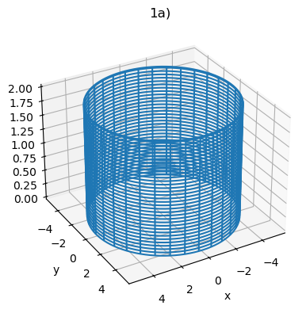

```python
fig = plt.figure(figsize=(10,10))

phi = np.linspace(0,2*np.pi,101)
z = np.linspace(0, 2, 101)
xx = np.zeros((101,101))
yy = np.zeros((101,101))
zz = np.zeros((101,101))
for i in range(101):
    xx[i] = 5*np.cos(phi)
    yy[i] = 5*np.sin(phi)
    zz[i] = z[i]
ax = fig.add_subplot(221, projection='3d')
ax.plot_wireframe(xx,yy,zz)
ax.view_init(30,60)
ax.set_xlabel('x')
ax.set_ylabel('y')
ax.set_title('1a)')
plt.show()
```

*3)*

- Umrechnung zwischen kartesisch und sphärisch:

$\begin{array}{l}x = r \sin(\vartheta)\cos(\varphi)\\ y = r \sin(\vartheta) \sin(\varphi)\\ z= r \cos(\vartheta)\end{array} \;\;\;\;\;\;\;\;\; \mathbf{\vec{A}}_{sphärisch} = \left[\begin{array}{ccc} \sin(\vartheta)\cos(\varphi) & \sin(\vartheta)\sin(\varphi) & \cos(\vartheta) \\ \cos(\vartheta)\cos(\varphi) & \cos(\vartheta)\sin(\varphi) & -\sin(\vartheta) \\ -\sin(\varphi) & \cos(\varphi) & 0\end{array}\right] \mathbf{\vec{A}}_{kartesisch}$

- Transformation des Vektorfeldes:

$\mathbf{\vec{F}}_{sphärisch} = \left[\begin{array}{ccc} \sin(\vartheta)\cos(\varphi) & \sin(\vartheta)\sin(\varphi) & \cos(\vartheta) \\ \cos(\vartheta)\cos(\varphi) & \cos(\vartheta)\sin(\varphi) & -\sin(\vartheta) \\ -\sin(\varphi) & \cos(\varphi) & 0\end{array}\right] \left[\begin{array}{c} x \\ -z \\ y \end{array}\right]$

$ \qquad \qquad = \left[\begin{array}{ccc} \sin(\vartheta)\cos(\varphi) & \sin(\vartheta)\sin(\varphi) & \cos(\vartheta) \\ \cos(\vartheta)\cos(\varphi) & \cos(\vartheta)\sin(\varphi) & -\sin(\vartheta) \\ -\sin(\varphi) & \cos(\varphi) & 0\end{array}\right] \left[\begin{array}{c} r \sin(\vartheta)\cos(\varphi) \\ -r \cos(\vartheta) \\ r \sin(\vartheta) \sin(\varphi) \end{array}\right] = \left[\begin{array}{c} r \sin^2(\vartheta)\cos^2(\varphi) \\ r \sin(\vartheta)\cos^2(\varphi)\cos(\vartheta) - r \sin(\varphi)\\ -r \sin(\vartheta)\cos(\varphi)\sin(\varphi) -r \cos(\vartheta) \cos(\varphi) \end{array}\right]$

$ \qquad \qquad = r \sin^2(\vartheta)\cos^2(\varphi) \mathbf{\vec{e}}_r + r \left[\sin(\vartheta)\cos^2(\varphi)\cos(\vartheta) - \sin(\varphi)\right]\mathbf{\vec{e}}_{\vartheta} - r\cos(\varphi) \left[\sin(\vartheta)\sin(\varphi) + \cos(\vartheta)\right]\mathbf{\vec{e}}_{\varphi}$

*4)*

- Bestimmung der Geschwindigkeit in kartesischen Koordinaten

$$\dfrac{\mathrm{d} \mathbf{\vec{r}}}{\mathrm{d} t} = \mathbf{\vec{v}} =\left[\begin{array}{c} \dot{x}(t) \\ \dot{y}(t) \\ \dot{z}(t) \end{array}\right] = \left[\begin{array}{c} -\mathrm{e}^{-t} \cos(t) - \mathrm{e}^{-t} \sin(t) \\ -\mathrm{e}^{-t} \sin(t) + \mathrm{e}^{-t} \cos(t) \\ 2 \end{array}\right]$$

- Umrechnung in Zylinderkoordinaten

$$\mathbf{\vec{v}}_{ZK} = \left[\begin{array}{c} \cos(\varphi) & \sin(\varphi) & 0 \\ -\sin(\varphi) & \cos(\varphi) & 0 \\ 0 & 0 & 1\end{array}\right]\mathbf{\vec{v}_{KK}} = \left[\begin{array}{c} -\mathrm{e}^{-t} (\cos(t) + \sin(t))\cos(\varphi) + \mathrm{e}^{-t} (\cos(t) - \sin(t))\sin(\varphi) \\ \mathrm{e}^{-t} (\cos(t) + \sin(t))\sin(\varphi) + \mathrm{e}^{-t} (\cos(t) - \sin(t))\cos(\varphi) \\ 2 \end{array}\right]$$

- Beziehung der Variablen

$$ \tan(\varphi) = \dfrac{y}{x} = \dfrac{\mathrm{e}^{-t} \sin(t)}{\mathrm{e}^{-t} \cos(t)} = \tan(t) \; \rightarrow \; \varphi = t$$

dadurch ergibt sich

$$\mathbf{\vec{v}}_{ZK} =\left[\begin{array}{c} -\mathrm{e}^{-t} \\ \mathrm{e}^{-t} \\ 2 \end{array}\right] = -\mathrm{e}^{-t} \mathbf{\vec{e}_r} + \mathrm{e}^{-t} \mathbf{\vec{e}_\varphi} + 2 \mathbf{\vec{e}_z}$$

*Alternative:* Einsetzen in die Formel $\mathbf{\dot{\vec{v}}} = \dot{r}\mathbf{\vec{e}_r} + (r \dot{\varphi}) \mathbf{\vec{e}_\varphi} + \dot{z} \mathbf{\vec{e}_z}$